# Biostat 203B Homework 2 Solutions

Due Feb 5 Feb 12 @ 11:59PM

Yingyan Wu

```r
knitr::opts_chunk$set(echo = TRUE, cache = TRUE)
# default cache is false, previous result are saved!

if (!require("pacman")){
  install.packages("pacman", repos='http://cran.us.r-project.org')
}
p_load("here", "readr", "tidyverse", "magrittr", "plyr", "haven", "labelled",
       "lubridate", "data.table")
```

```r
os <- sessionInfo()$running
if (str_detect(os, "Linux")) {
  mimic_path <- "/usr/203b-data/mimic-iv"
  mimic_derived_path <- "/usr/203b-data/mimic-iv-derived-data"
} else if (str_detect(os, "Windows")) {
  mimic_path <- "C:/Users/Yingyan Wu/Documents/Dataset/mimic-iv"
  mimic_derived_path <-
    "C:/Users/Yingyan Wu/Documents/Dataset/mimic-iv-derived-data"
}
```

Use tidyverse (ggpot2, dplyr) to explore the [MIMIC-IV](https://mimic-iv.mit.edu) data introduced in [homework 1](https://ucla-biostat203b-2021winter.github.io/hw/hw1/hw1.html).

```r
system(str_c("tree -s -L 2 ", shQuote(mimic_path)), intern = TRUE)
```

```
## [1] "Too many parameters - -L"
```

## Q1. PhysioNet credential

At this moment, you should already get credentialed on the PhysioNet. Please include a screenshot of your `Data Use Agreement for the MIMIC-IV (v0.4)`.

**Solution**:

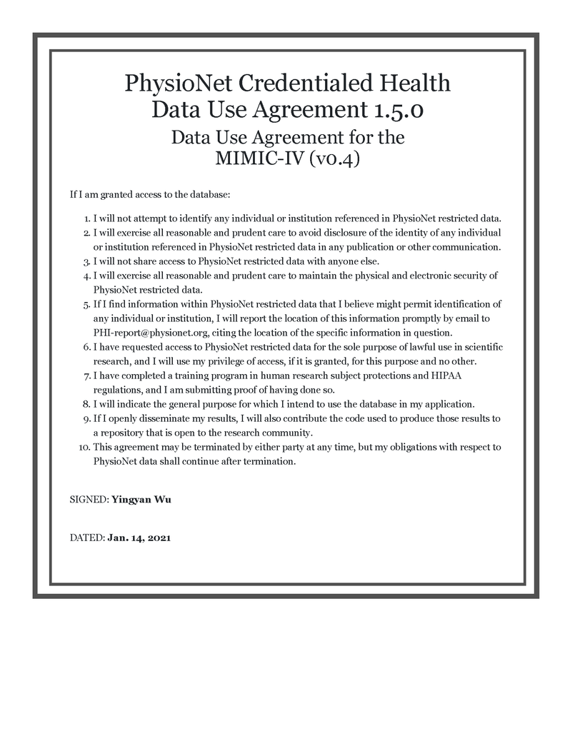

## Q2. `read.csv` (base R) vs `read_csv` (tidyverse) vs `fread` (data.table)

There are quite a few utilities in R for reading data files. Let us test the speed of reading a moderate sized compressed csv file, `admissions.csv.gz`, by three programs: `read.csv` in base R, `read_csv` in tidyverse, and `fread` in the popular data.table package. Is there any speed difference?

In this homework, we stick to the tidyverse.

**Solution**:

```r
system.time(read.csv(paste0(mimic_path, "/core/admissions.csv.gz")))
```

```
##    user  system elapsed
##    8.85    0.14    9.00
```

```r
system.time(read_csv(paste0(mimic_path, "/core/admissions.csv.gz")))
```

```
##    user  system elapsed
##    2.35    1.16    3.48
```

```r
system.time(fread(paste0(mimic_path, "/core/admissions.csv.gz")))
```

```
##    user  system elapsed
##    1.30    0.61    2.38
```

## Q3. ICU stays

`icustays.csv.gz` (https://mimic-iv.mit.edu/docs/datasets/icu/icustays/) contains data about Intensive Care Units (ICU) stays. Summarize following variables using appropriate numerics or graphs:

- how many unique `stay_id`?
- how many unique `subject_id`?
- length of ICU stay
- first ICU unit
- last ICU unit

**Solution**:

```r
# Load the icustays.csv.gz
icustays <- read_csv(paste0(mimic_path, "/icu/icustays.csv.gz")) %>%
  print(width = Inf)
```

```
## # A tibble: 69,619 x 8
##    subject_id  hadm_id  stay_id first_careunit
##         <dbl>    <dbl>    <dbl> <chr>
##  1   17823467 27561644 35964304 Coronary Care Unit (CCU)
##  2   15772648 26147926 39637383 Trauma SICU (TSICU)
##  3   13713711 25848902 36363748 Trauma SICU (TSICU)
##  4   13173210 22338446 38210858 Coronary Care Unit (CCU)
##  5   10213765 28522861 39765853 Trauma SICU (TSICU)
##  6   17530304 21776160 35848367 Trauma SICU (TSICU)
##  7   10297774 20364526 37788595 Coronary Care Unit (CCU)
##  8   16766597 21185791 39262919 Trauma SICU (TSICU)
##  9   17684317 28656350 36989766 Trauma SICU (TSICU)
## 10   15693895 21203492 34766377 Surgical Intensive Care Unit (SICU)
##    last_careunit                       intime              outtime
##    <chr>                               <dttm>              <dttm>
```

[output cut: 23 more lines]

```r
# Check unique stay_id
icustays %>%
  distinct(stay_id) %>%
  nrow()
```

```
## [1] 69619
```

```r
# Check unique subject_id
icustays %>%
  distinct(subject_id) %>%
  nrow()
```

```
## [1] 50048
```

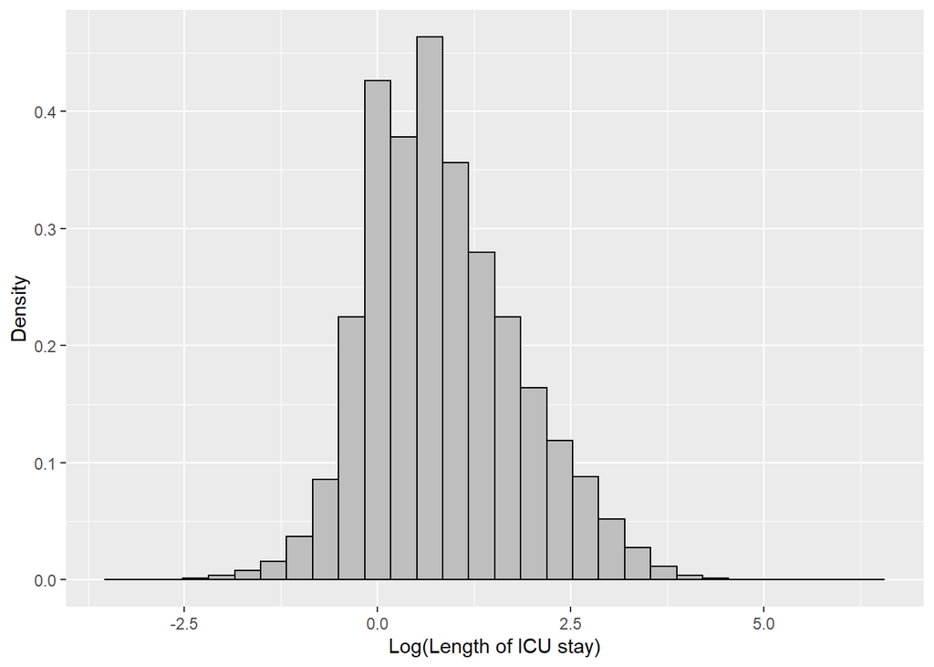

```r
par(mfrow=c(1,2))
# Length of stay
icustays %>%
  ggplot(aes(x = log(los))) +
  geom_histogram(
    aes(y=..density..), colour = "black", fill = "grey", bins = 30) +
  xlab("Log(Length of ICU stay)") + ylab("Density")
```

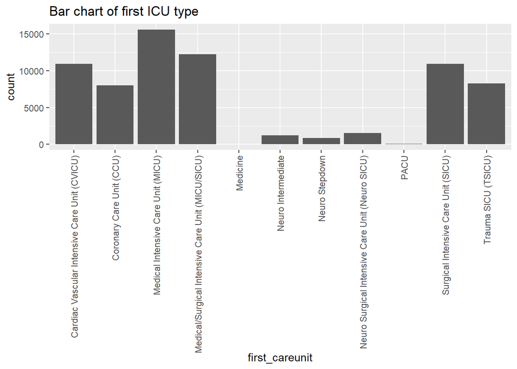

```r
# Another option to plot ICU stay (using ouottime and intime to calculate)
# icustays %>%
#   mutate(totaltime = as.numeric(outtime - intime)) %>%
#   select(totaltime) %>%
#   ggplot(aes(x = log(totaltime))) +
#   geom_histogram(aes(y=..density..), colour = "black", fill = "grey",
#   bins = 30) +
#   xlab("Log(total ICU stay)") + ylab("Density")

# First ICU unit

icustays %>%
  ggplot(aes(x = first_careunit)) +
  geom_bar(aes(x = first_careunit)) +
  theme(axis.text.x = element_text(angle = 90, vjust = 0.5, hjust = 1)) +
  labs(title = "Bar chart of first ICU type")
```

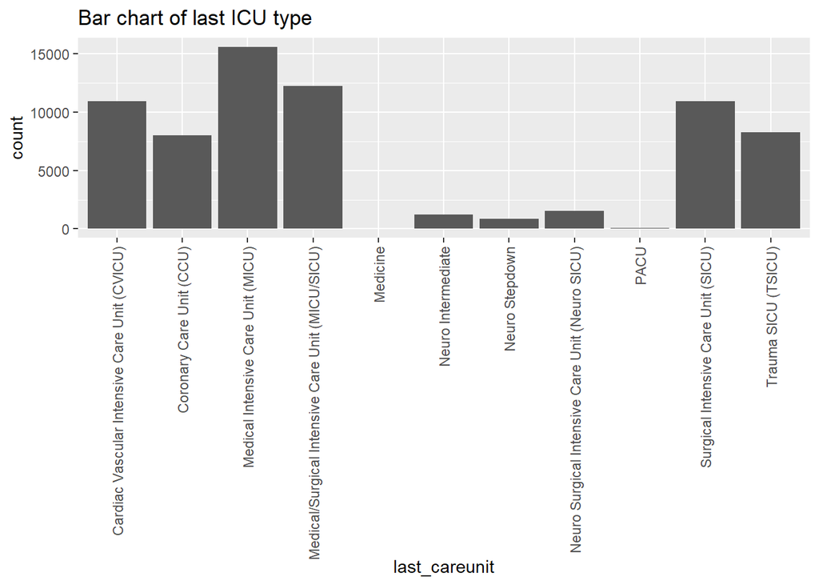

```r
# Last ICU unit
icustays %>%
  ggplot(aes(x = last_careunit)) +
  geom_bar(aes(x = first_careunit)) +
  theme(axis.text.x = element_text(angle = 90, vjust = 0.5, hjust = 1)) +
  labs(title = "Bar chart of last ICU type")
```

There are 69619 unique `stay_id` in the `icustays` dataset and 50048 unique `subject_id` in the dataset.50048 patients having 69619 ICU stays are included in the dataset.

## Q4. `admission` data

Information of the patients admitted into hospital is available in `ADMISSION.csv.gz`. See https://mimic-iv.mit.edu/docs/datasets/core/admissions/ for details of each field in this file. Summarize following variables using appropriate graphs. Explain any patterns you observe.

- admission year
- admission month
- admission month day
- admission week day
- admission hour (anything unusual?)
- number of deaths in each year
- admission type
- number of admissions per patient
- admission location
- discharge location
- insurance
- language
- martial status
- ethnicity
- death

Note it is possible that one patient (uniquely identified by the `SUBJECT_ID`) is admitted into hospital multiple times. When summarizing some demographic information, it makes sense to summarize based on unique patients.

**Solution**:

```r
# Load the admissions.csv.gz
admissions <- read_csv(paste0(mimic_path, "/core/admissions.csv.gz"))  %>%
  print(width = Inf)
```

```
## # A tibble: 524,520 x 15
##    subject_id  hadm_id admittime           dischtime
##         <dbl>    <dbl> <dttm>              <dttm>
##  1   12427812 21593330 2184-01-06 11:51:00 2184-01-10 11:45:00
##  2   14029832 22059088 2120-01-18 01:28:00 2120-01-20 16:13:00
##  3   14495017 22484010 2175-01-28 15:41:00 2175-01-29 16:00:00
##  4   13676048 23865469 2193-01-19 05:27:00 2193-01-24 18:59:00
##  5   13831972 27763544 2131-01-27 04:03:00 2131-01-27 05:39:00
##  6   18523038 25414328 2142-08-26 17:14:00 2142-08-27 10:00:00
##  7   16705931 20580522 2174-10-24 11:30:00 2174-10-24 18:45:00
##  8   19963742 24951506 2171-07-04 15:58:00 2171-07-05 13:37:00
##  9   10903424 22568585 2181-01-31 13:09:00 2181-01-31 13:42:00
## 10   15030422 21975876 2149-09-21 23:54:00 2149-09-22 03:59:00
##    deathtime           admission_type         admission_location
##    <dttm>              <chr>                  <chr>
```

[output cut: 35 more lines]

```r
# get the components
admissions %<>%
  mutate("admityear" = year(as_datetime(admittime)),
         "admitmonth" = month(as_datetime(admittime)),
         "admitmonthday" = mday(as_datetime(admittime)),
         "admitweekday" = wday(as_datetime(admittime)),
         "admithour" = hour(as_datetime(admittime)),
         "deathyear" = year(as_datetime(deathtime))
         )

# To get dataset with only unique subject_id
uniq_admissions <- admissions %>%
  distinct(., subject_id, .keep_all = T)

#---- admission year ----
# Get the # of admission year value in the dataset
length(unique(admissions$admityear))
```

```
## [1] 105
```

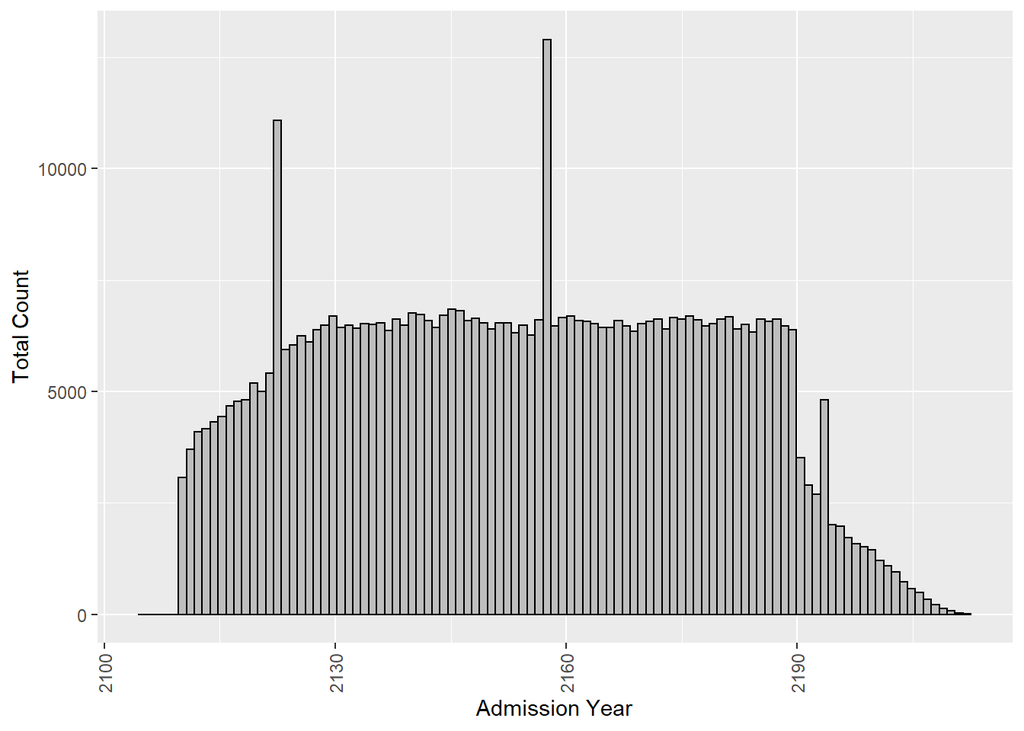

```r
admissions %>%
  ggplot(aes(x = admityear)) +
  geom_histogram(aes(y = ..count..),
                 colour = "black", fill = "grey", bins = 105) +
  xlab("Admission Year") +
  ylab("Total Count") +
  theme(axis.text.x = element_text(angle = 90, vjust = 0.5, hjust = 1))
```

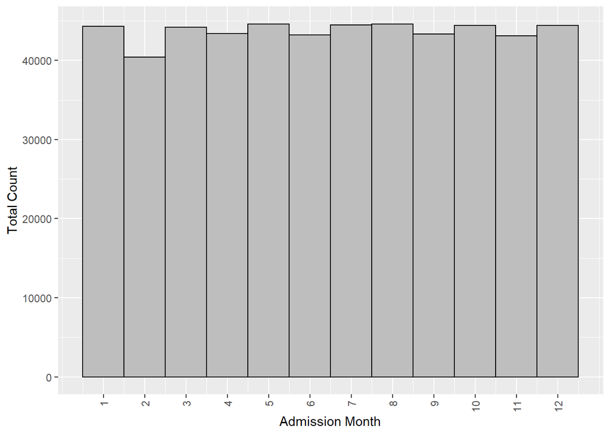

```r
#---- admission month ----
admissions %>%
  ggplot(aes(x = admitmonth)) +
  geom_histogram(aes(y = ..count..),
                 colour = "black", fill = "grey", bins = 12) +
  xlab("Admission Month") +
  ylab("Total Count") +
  scale_x_continuous(breaks = seq(1, 12, 1)) +
  theme(axis.text.x = element_text(angle = 90, vjust = 0.5, hjust = 1))
```

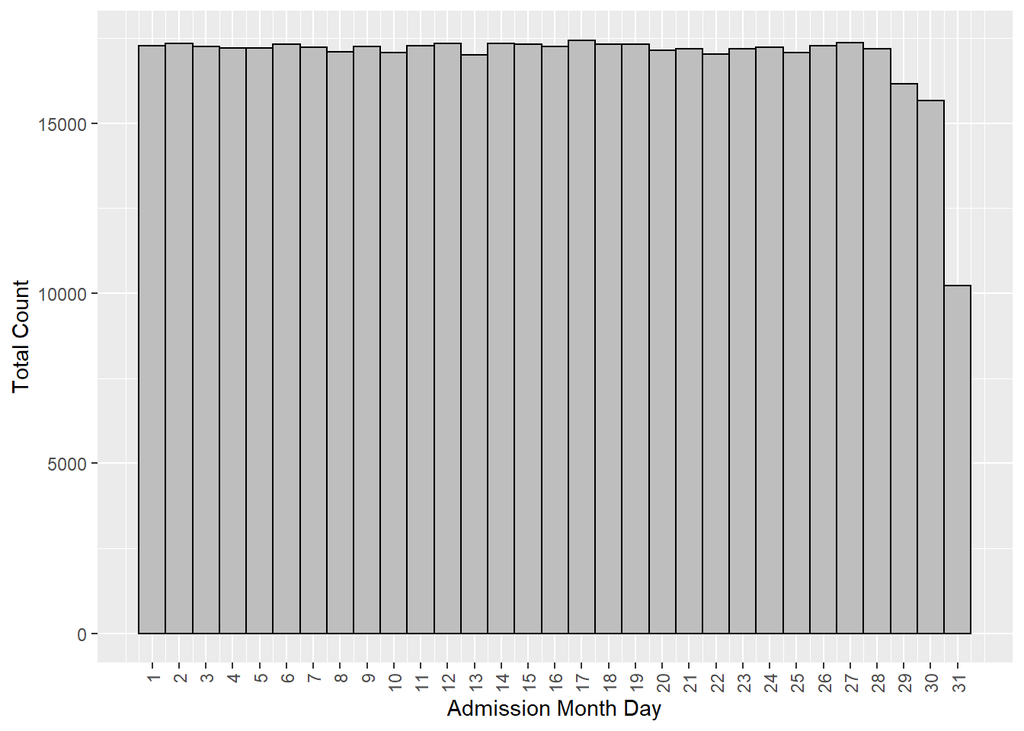

```r
#---- admission month day ----
admissions %>%
  ggplot(aes(x = admitmonthday)) +
  geom_histogram(aes(y = ..count..),
                 colour = "black", fill = "grey", bins = 31) +
  xlab("Admission Month Day") +
  ylab("Total Count") +
  scale_x_continuous(breaks = seq(1, 31, 1)) +
  theme(axis.text.x = element_text(angle = 90, vjust = 0.5, hjust = 1))
```

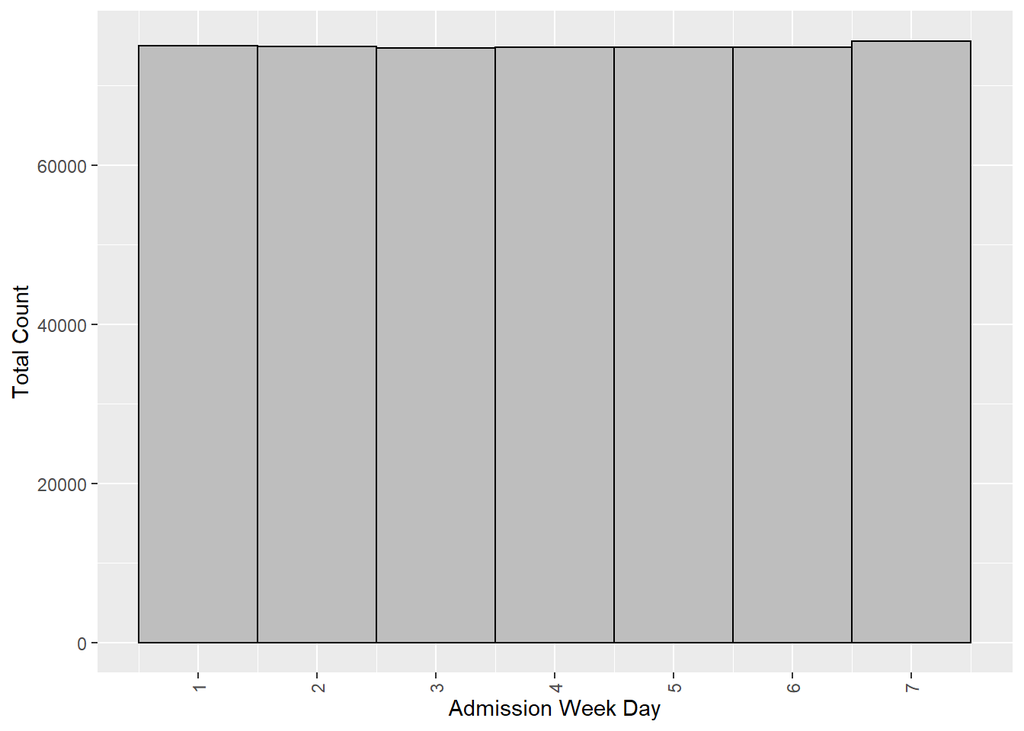

```r
#---- admission week day ----
admissions %>%
  ggplot(aes(x = admitweekday)) +
  geom_histogram(aes(y = ..count..),
                 colour = "black", fill = "grey", bins = 7) +
  xlab("Admission Week Day") +
  ylab("Total Count") +
  scale_x_continuous(breaks = seq(1, 7, 1)) +
  theme(axis.text.x = element_text(angle = 90, vjust = 0.5, hjust = 1))
```

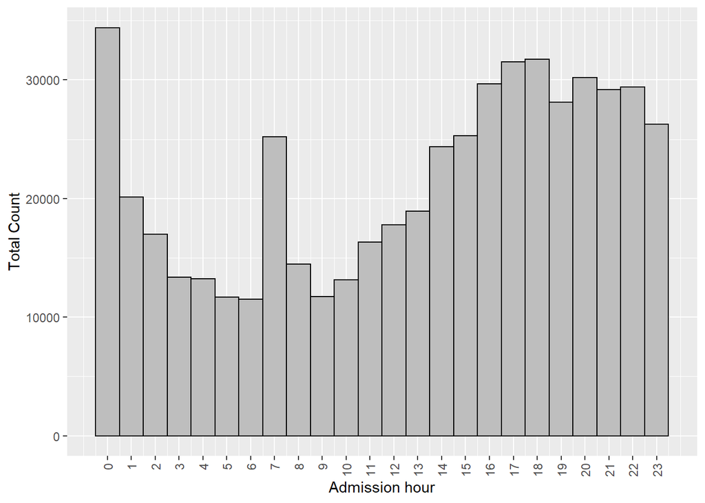

```r
#---- admission hour ----
admissions %>%
  ggplot(aes(x = admithour)) +
  geom_histogram(aes(y = ..count..),
                 colour = "black", fill = "grey", bins = 24) +
  xlab("Admission hour") +
  ylab("Total Count") +
  scale_x_continuous(breaks = seq(0, 23, 1)) +
  theme(axis.text.x = element_text(angle = 90, vjust = 0.5, hjust = 1))
```

```r
#---- number of death in each year ----
table(admissions$deathyear, useNA = "ifany")
```

```
##
##   2110   2111   2112   2113   2114   2115   2116   2117   2118   2119   2120
##     64     69     74     89     85     88     94     96     95    107     72
##   2121   2122   2123   2124   2125   2126   2127   2128   2129   2130   2131
##    104    111    102     97    102    116    120    120    108    130    133
##   2132   2133   2134   2135   2136   2137   2138   2139   2140   2141   2142
##    118    132    129    129    103    118    132    123    117    124    111
##   2143   2144   2145   2146   2147   2148   2149   2150   2151   2152   2153
##    110    118    112    117    126    100    126    121    109    119    107
##   2154   2155   2156   2157   2158   2159   2160   2161   2162   2163   2164
##    117    116    117    116    120    110    118    115     97    117    133
##   2165   2166   2167   2168   2169   2170   2171   2172   2173   2174   2175
##    115    119    115    107    113    120    121    117    101    112    129
##   2176   2177   2178   2179   2180   2181   2182   2183   2184   2185   2186
##    122    122    124    126    122    115    122    105     88    142    116
##   2187   2188   2189   2190   2191   2192   2193   2194   2195   2196   2197
##    114    113    114     49     35     35     33     25     28     17     24
##   2198   2199   2200   2201   2202   2203   2204   2205   2206   2207   2208
##     19     23     13     17     12     13     13      8      8      4      6
##   2209   2210   2211   <NA>
##      3      3      1 515164
```

```r
length(unique(admissions$deathyear))
```

```
## [1] 103
```

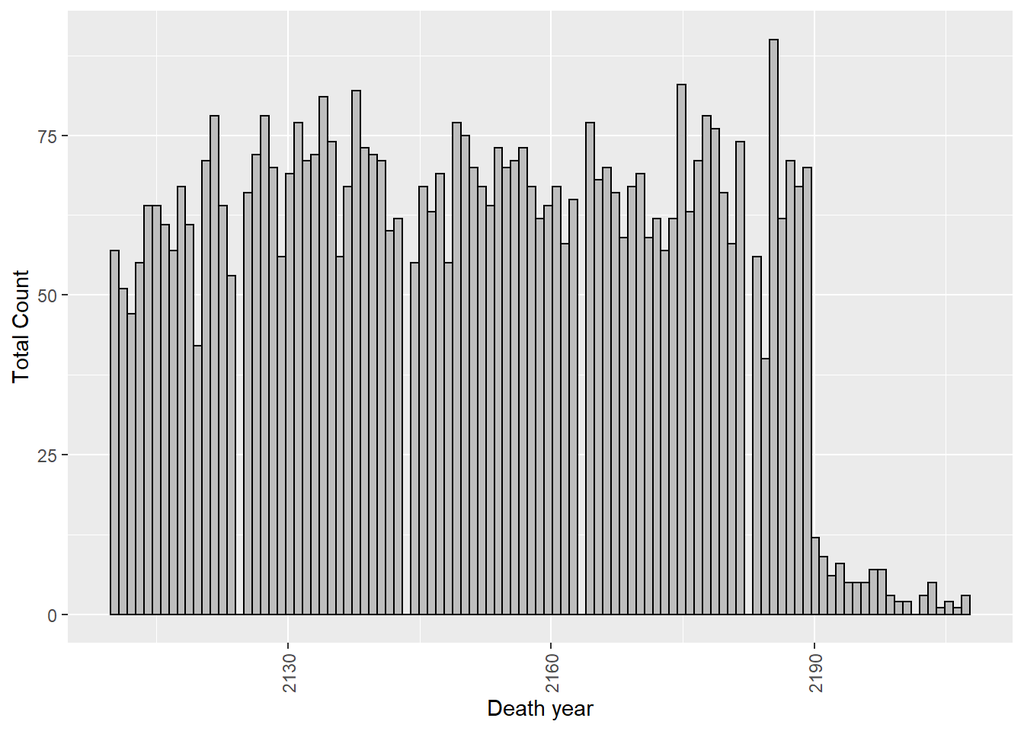

```r
uniq_admissions %>%
  ggplot(aes(x = deathyear)) +
  geom_histogram(aes(y = ..count..),
                 colour = "black", fill = "grey", bins = 103) +
  xlab("Death year") +
  ylab("Total Count") +
  theme(axis.text.x = element_text(angle = 90, vjust = 0.5, hjust = 1))
```

```r
#---- # of admissions per patient ----
num_admissions <- admissions %>%
  group_by(subject_id) %>%
  dplyr::summarise(count = n())
length(unique(num_admissions$count))
```

```
## [1] 95
```

```r
table(num_admissions$count, useNA = "ifany")
```

```
##
##      1      2      3      4      5      6      7      8      9     10     11
## 171439  39312  17072   9268   5523   3550   2426   1789   1369    991    801
##     12     13     14     15     16     17     18     19     20     21     22
##    626    498    420    327    251    198    177    148    150    101    108
##     23     24     25     26     27     28     29     30     31     32     33
##     73     72     54     52     57     40     32     40     31     29     30
##     34     35     36     37     38     39     40     41     42     43     44
##     21     29     22     19     11     12     14     16     10      6     14
##     45     46     47     48     49     50     51     52     53     54     55
##      6      6      8      7     11      6      5      5      7      2      7
##     56     57     58     59     60     61     62     63     64     65     67
##      4      3      5      2      2      1      2      1      6      1      2
##     68     69     70     71     72     75     76     77     78     79     80
##      3      3      1      3      1      1      1      1      1      2      1
##     82     84     85     86     88     89     92     93     94     95     97
##      1      2      1      1      1      2      2      1      1      1      1
##     98    129    130    142    163    185    238
##      1      1      1      1      1      1      1
```

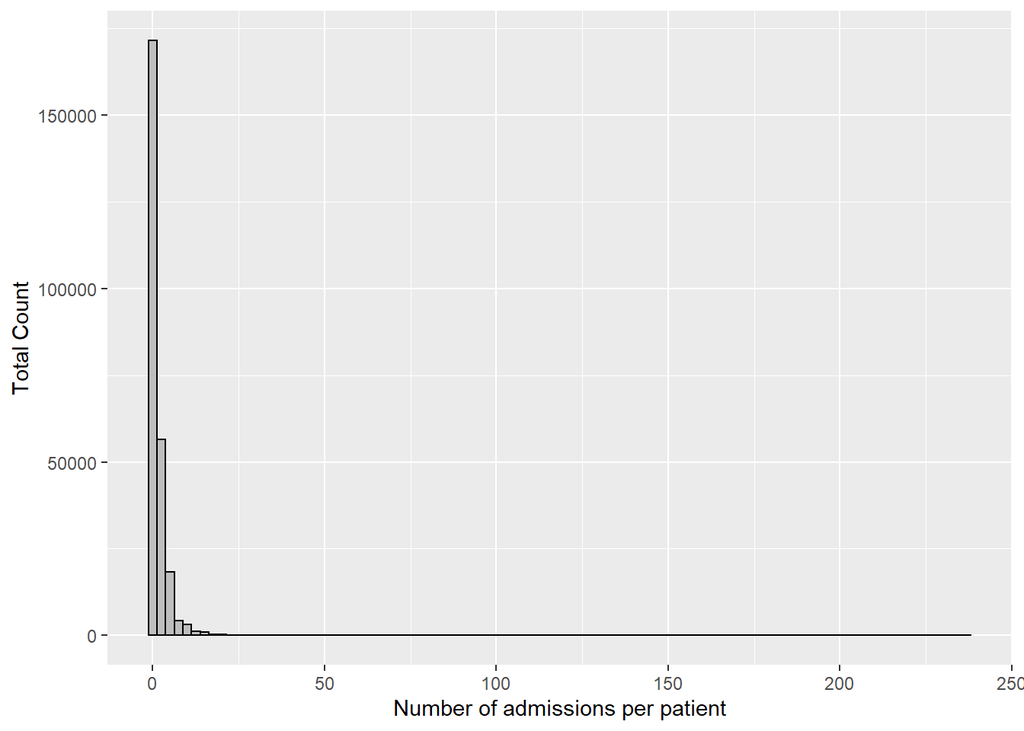

```r
num_admissions %>%
  ggplot(aes(x = count)) +
  geom_histogram(aes(y = ..count..),
                 colour = "black", fill = "grey", bins = 95) +
  xlab("Number of admissions per patient") +
  ylab("Total Count")
```

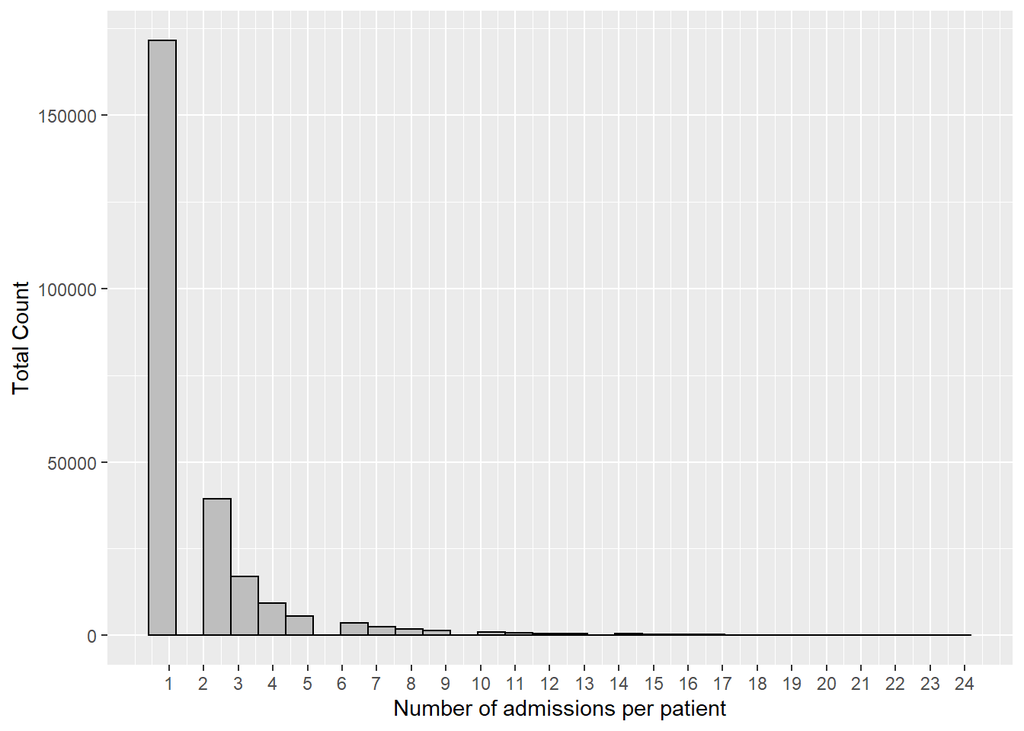

```r
# filter the count
num_admissions %>%
  filter(count < 25) %>%
  ggplot(aes(x = count)) +
  geom_histogram(aes(y = ..count..),
                 colour = "black", fill = "grey") +
  scale_x_continuous(breaks = seq(1, 24, 1)) +
  xlab("Number of admissions per patient") +
  ylab("Total Count")
```

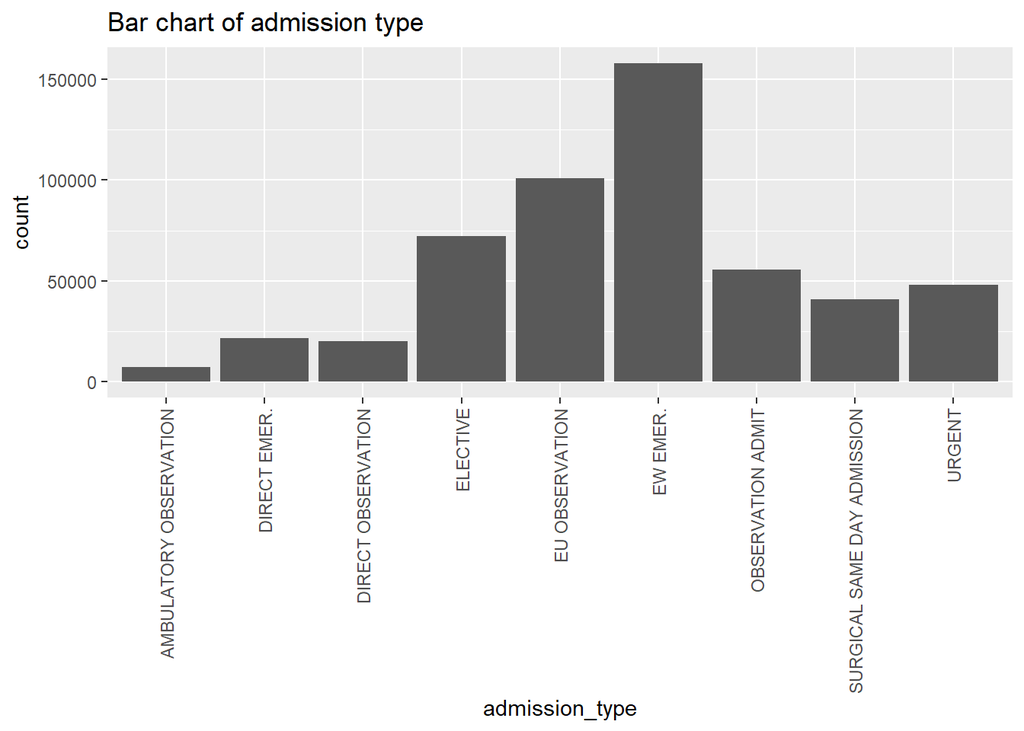

```r
#---- Admission type ----
admissions %>%
  ggplot(aes(x = admission_type)) +
  geom_bar(aes(x = admission_type)) +
  theme(axis.text.x = element_text(angle = 90, vjust = 0.5, hjust = 1)) +
  labs(title = "Bar chart of admission type")
```

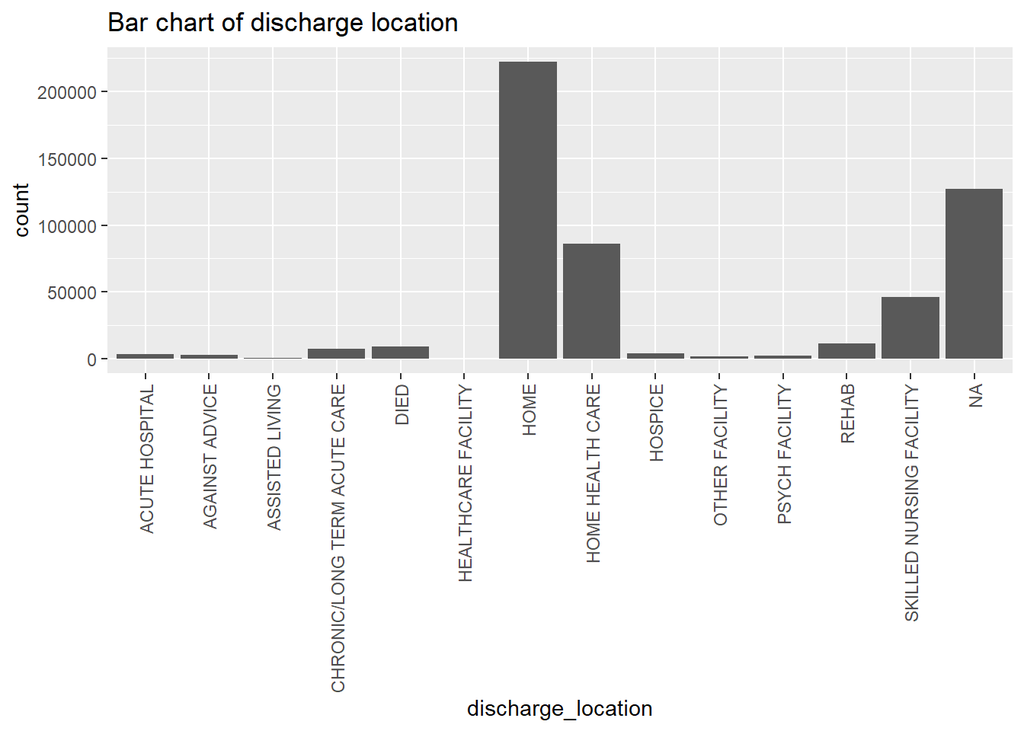

```r
#---- discharge location ----
admissions %>%
  ggplot(aes(x = discharge_location)) +
  geom_bar(aes(x = discharge_location)) +
  theme(axis.text.x = element_text(angle = 90, vjust = 0.5, hjust = 1)) +
  labs(title = "Bar chart of discharge location")
```

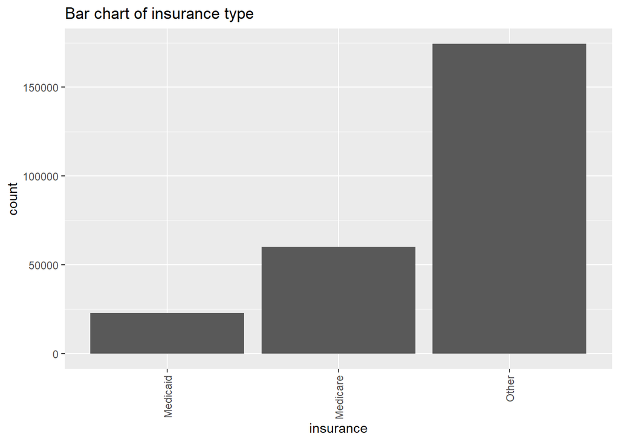

```r
#---- Insurance ----
uniq_admissions %>%
  ggplot(aes(x = insurance)) +
  geom_bar(aes(x = insurance)) +
  theme(axis.text.x = element_text(angle = 90, vjust = 0.5, hjust = 1)) +
  labs(title = "Bar chart of insurance type")
```

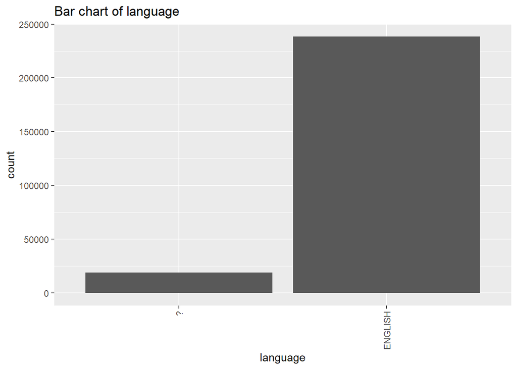

```r
#---- Language ----
uniq_admissions %>%
  ggplot(aes(x = language)) +
  geom_bar(aes(x = language)) +
  theme(axis.text.x = element_text(angle = 90, vjust = 0.5, hjust = 1)) +
  labs(title = "Bar chart of language")
```

```r
table(uniq_admissions$language, useNA = "ifany")
```

```
##
##       ? ENGLISH
##   18979  238387
```

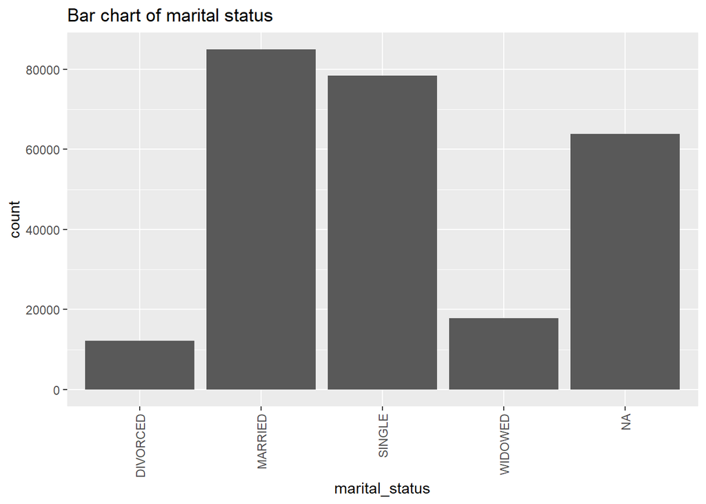

```r
#---- marital status ----
uniq_admissions %>%
  ggplot(aes(x = marital_status)) +
  geom_bar(aes(x = marital_status)) +
  theme(axis.text.x = element_text(angle = 90, vjust = 0.5, hjust = 1)) +
  labs(title = "Bar chart of marital status")
```

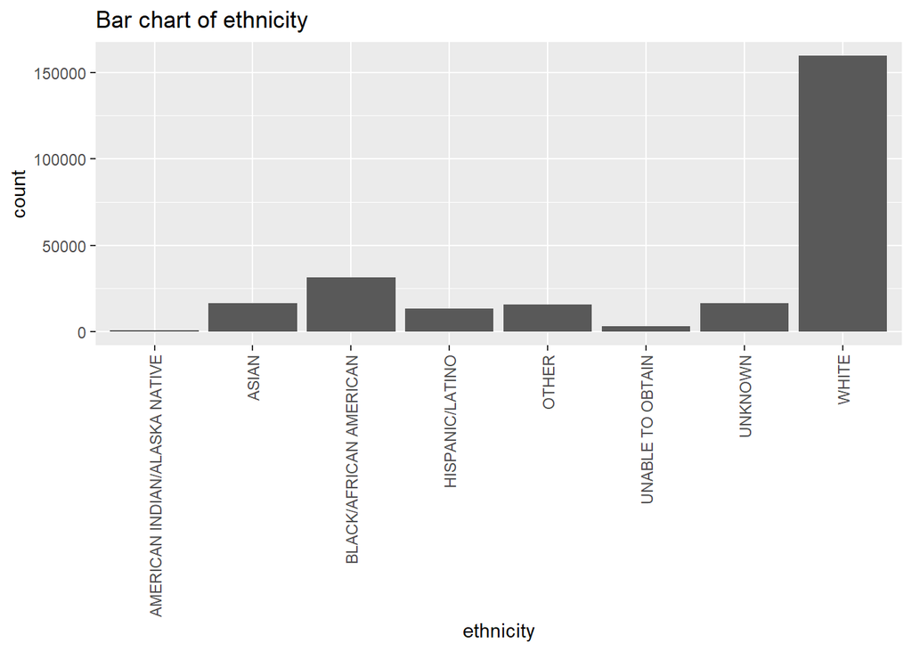

```r
#---- ethnicity ----
uniq_admissions %>%
  ggplot(aes(x = ethnicity)) +
  geom_bar(aes(x = ethnicity)) +
  theme(axis.text.x = element_text(angle = 90, vjust = 0.5, hjust = 1)) +
  labs(title = "Bar chart of ethnicity")
```

```r
#---- Death ----
#Check the concordance of deathtime and hospital_expire_flag
table(!is.na(admissions$deathtime),
      admissions$hospital_expire_flag, useNA = "ifany")
```

```
##
##              0      1
##   FALSE 515151     13
##   TRUE       0   9356
```

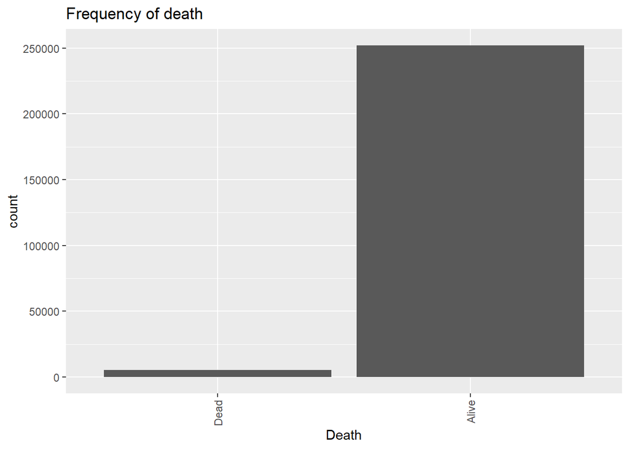

```r
# Use deathtime as a death indicator
uniq_admissions %>%
  ggplot(aes(x = is.na(deathtime))) +
  geom_bar(aes(x = is.na(deathtime))) +
  theme(axis.text.x = element_text(angle = 90, vjust = 0.5, hjust = 1)) +
  labs(title = "Frequency of death") +
  xlab("Death") +
  scale_x_discrete(labels = c("Dead", "Alive"))
```

**Admission time**:

For admission year, there is a huge drop for admissions after shifted year 2190. There isn’t a specific pattern for a peak for a month with lots of admissions. For admission month day, the number of admissions drop drastically on 31 day of each month because there are only 7 months with a day 31.Overall, the end of the month have less admissions than the other days of each month. The week days don’t differentiate much for admission numbers.

For admission hour, there is a peak for number of admissions occurred at midnight. However, the number rise again at 7 AM. I’m not too sure why is this pattern.It probably has something to do with shifting of duty for senior and junior residents. The other possible reason is that this is when people wake up and they just found out what happened to the patients.

**Death year**:

There is a drastical drop for death after 2190 which aligns with the admission year.

**Number of admissions per patient**:

There are over a half of the patients in the admissions dataset has only one admission.The maximum of # of admissions per patient is 238. Most of the patients are admitted to ICU with less than 25 times.

**Admission type**:

The most common admission type is EW emergency followed by EU observation and Elective.

**Discharge location**:

The most common discharge location is Home and there are over 75000 patients missing this information.

**Insurance type**:

The most common insurance type is insurance other than Medicaid and Medicare. There are more patients with a Medicare insurance than Medicaid.

**Language**:

Most of the patients speak English while nearly 20000 patients don’t.

**Marital status**:

**Ethnicity**:

Most of the admitted patients are White.

**Death**:

There are two variables indicating the whether the patient died in the hospitalization. Based on the crosstab made to check the concordance, varaible `hospital_expire_flag` indicates 13 more deaths than the `deathtime`. To be conservative to the analysis, the `deathtime` is used to indicate whether the patient died within hospitalization.

There are 9356 death in the dataset.

## Q5. `patient` data

Explore `patients.csv.gz` (https://mimic-iv.mit.edu/docs/datasets/core/patients/) and summarize following variables using appropriate numerics and graphs:

- `gender`
- `anchor_age` (explain pattern you see)

**Solution**:

```r
patients <- read_csv(paste0(mimic_path, "/core/patients.csv.gz"))  %>%
  print(width = Inf)
```

```
## # A tibble: 383,220 x 6
##    subject_id gender anchor_age anchor_year anchor_year_group dod
##         <dbl> <chr>       <dbl>       <dbl> <chr>             <lgl>
##  1   10002723 F               0        2128 2017 - 2019       NA
##  2   10003939 M               0        2184 2008 - 2010       NA
##  3   10004222 M               0        2161 2014 - 2016       NA
##  4   10005325 F               0        2154 2011 - 2013       NA
##  5   10007338 F               0        2153 2017 - 2019       NA
##  6   10008101 M               0        2142 2008 - 2010       NA
##  7   10009872 F               0        2168 2014 - 2016       NA
##  8   10011333 F               0        2132 2014 - 2016       NA
##  9   10011879 M               0        2158 2014 - 2016       NA
## 10   10012663 F               0        2171 2011 - 2013       NA
## # ... with 383,210 more rows
```

```r
# Gender
table(patients$gender, useNA = "ifany")
```

```
##
##      F      M
## 200226 182994
```

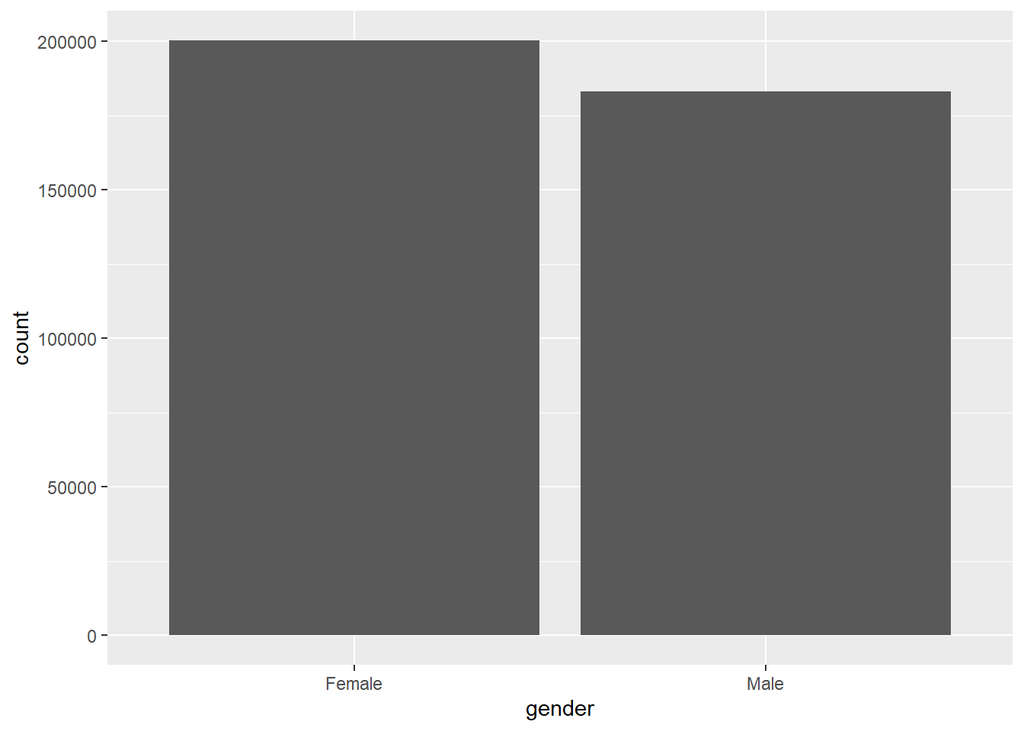

```r
patients %>%
  ggplot(aes(x = gender)) +
  geom_bar(aes(x = gender)) +
  scale_x_discrete(labels = c("Female", "Male"))
```

```r
# Anchor age
length(unique(patients$anchor_age))
```

```
## [1] 74
```

```r
table(patients$anchor_age, useNA = "ifany")
```

```
##
##     0    18    19    20    21    22    23    24    25    26    27    28    29
## 60879  4168  6985  9852  8575  8075  7632  6993  6398  6016  5828  5631  5337
##    30    31    32    33    34    35    36    37    38    39    40    41    42
##  5285  4990  4917  4690  4471  4380  4115  4065  4007  3912  3944  3862  3904
##    43    44    45    46    47    48    49    50    51    52    53    54    55
##  3878  3990  4195  4161  4219  4553  4552  4729  4742  5055  4866  5037  4911
##    56    57    58    59    60    61    62    63    64    65    66    67    68
##  4972  4826  4818  4945  4821  4812  4702  4646  4514  4345  4325  4206  4009
##    69    70    71    72    73    74    75    76    77    78    79    80    81
##  3927  3729  3636  3431  3291  3199  3078  3021  3006  2842  2752  2699  2694
##    82    83    84    85    86    87    88    89    91
##  2647  2414  2432  2314  2160  1941  1862  1161  7244
```

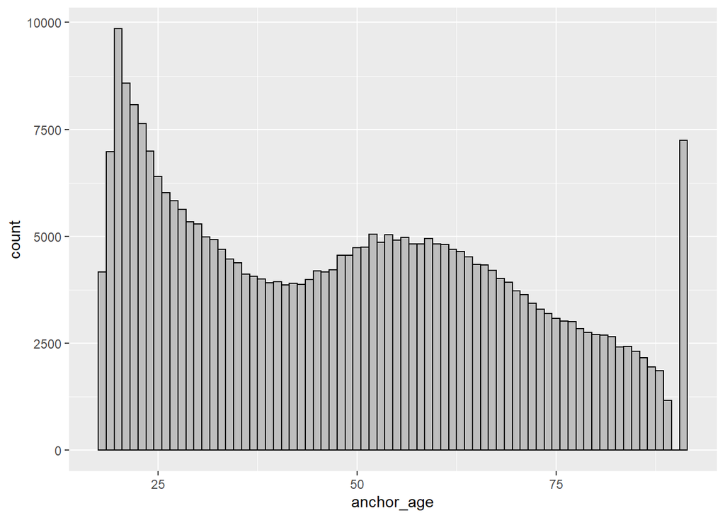

```r
patients %>%
  filter(anchor_age !=0) %>%
  select(anchor_age) %>%
  ggplot(aes(x = anchor_age)) +
  geom_histogram(aes(y = ..count..), position = "identity",colour = "black",
                 fill = "grey", bins = 74) +
  geom_density(alpha = 0.6)
```